# Submission 3 - Final

**Instructions**

- Fill out the 'Basic Information','Complex Hypotheses - Findings / Insights', 'Black vs White Hat Visualization' sections (replace the TODOs with your information)
  - If your visualization is interactive, create a short video that shows the interactivity (max. 3 min).
- Export the Jupyter notebook as a HTML file and save it in this repository.
  - Go to 'File' -> 'Save and Export Notebook As..' -> 'HTML'.
  - Save it locally in your project folder. You can leave the name as it is.
  - If you have a video, then add it to the project folder.
  - Push your local changes to the GitHub repository.
- Make sure all your files are up-to-date (pushed) in the Github repository.
  - Check if all Jupyter notebooks are executeable, theses will be the backup if there were problems with the HTML file submissions.
  - We will collect the protect via GitHub Classroom.

## Basic Information

**Team Name:** covid_2022

**Team Members:**

- Andeol Albitre
- Ábel Boros
- Felix Breiteneder
- Angelika Vižintin

**Dataset Description:**  
(max. 75 words)

Our dataset includes numerous statistics about the Covid-19 pandemic in Austria since its beginning. Daily number of infections, hospitalization and deaths are available among different age groups. Moreover, all of the data is aggregatable by states and disctricts. Additionally, the dataset also includes vaccine, test and available hospital beds statistics.

## Complex Hypotheses - Findings / Insights

**Instructions:**

- Add your visualizations (**max. 4**) here
  - The visualizations should show the findings / insights
- Add the descriptions for all your findings / insights (**max. 150 words**)
  - The description should also relate to the visualizations above.

## Hypothesis 1

### The number of normal and intensive care hospital beds occupied by patients with COVID-19 and number of deaths of patients with COVID-19 in all Austria decreased overtime as the cumulative number of administered doses of the vaccine against COVID-19 increased.

[figure not shown]

Figure 1: Cumulative number of administered COVID-19 vaccine doses, number of daily deaths and number of occupied normal and intesive care hospital beds until 10.11.2022 (source of data: https://covid19-dashboard.ages.at/).

## Hypothesis 2

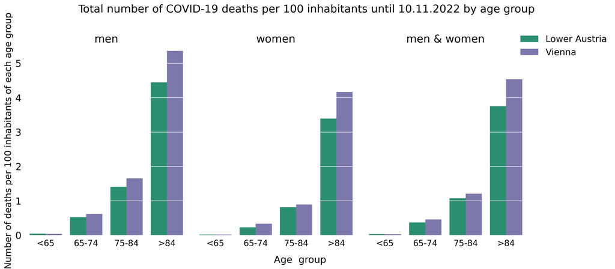

### Description

For our first complex hypothesis we used a logarithmic scaling to illustrate the decrease over time. However, that decrease is only clearly visible for the number of daily deaths and the number of occupied intensive beds by Covid-19 patients. Hence we contradict the hyptothesis for the number of occupied normal beds by Covid-19 patients.

## Black vs White Hat Visualization

### Black Hat Visualization

**Instructions:**

- Add your black hat visualization
- Add a description explaining your motivation and design process in producing this visualization (**max. 150 words**)

#### Visualization

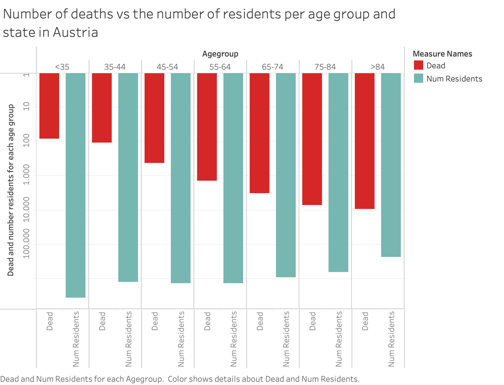

#### Description

The plot shows the death count and the number of residents by age group. We used a logaritmich scale and the axes are inverted so that it appears at the first glance that the number of deaths was very high, for example for the >84 age group it seems that 3/4 of the people died.

### White Hat Visualization

**Instructions:**

- Add your white hat visualization
- Add a description explaining your motivation and design process in producing this visualization (**max. 150 words**)

#### Visualization

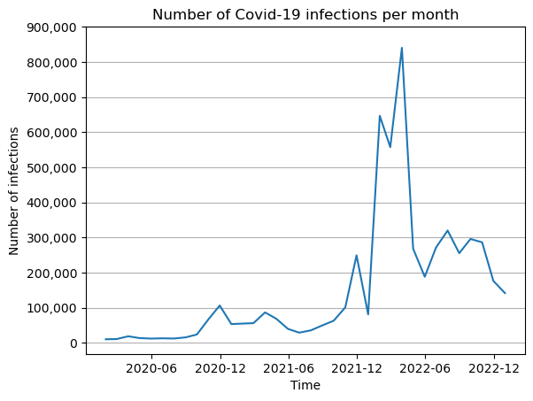

#### Description

Plot shows number of Covid-19 infections aggregated by month. Line histogram was used as the data is a ditribution with many data points.The data was grouped by month to make it more legible. The y-axis grid, bi-annual time ticks and thousands separators were used to make the plot easier to read. (source of data: https://covid19-dashboard.ages.at/).